# markr demo

## Read data

You can read in all the data from a table format like CSV or Excel, or from a format called YAML. YAML is easier for giving paragraphs of feedback, but the formatting can be a little tricky.

You can also combine data from tabular and YAML files, putting info like student IDs and category marks in a table and paragraphs of feedback in the YAML file.

```r
# all data in one table (csv or excel)
marks <- read_marks("marks_fb.csv")

# all data in one YAML file
# marks <- read_marks(yaml = "marks_fb.yml")

# or join data from table and YAML
# marks <- read_marks("marks.csv", "fb.yml", "ID")
```

## Data processing

You can do some optional further data processing. For example, the marks table had a column called `mark` with the numeric mark, but the feedback template needs a column called `grade` with the letter grade. The function `convert_grades()` defaults to the Glasgow 22-point scale, but you can define your own scale.

```r
scale <- data.frame(
  numbers = 4:0,
  letters = c("A", "B", "C", "D", "E")
)
marks$grade <- convert_grades(marks$mark, "letter", scale)
```

## Edit the template

Open the file called `template.Rmd`. It is written in R Markdown. The main thing you need to know at first is how to use hash marks to create titles and subtitles (the more hash marks, the lower-level subtitle) and how to edit inline code.

### Inline code

The information for each individual student will be stored in a list called `student`, and you can reference each column like this: `student$id`. If the column names have spaces or special characters, you can use this format: `student[["ID Number"]]`.

To insert information from a column into the text, you use this format: `` `r student$marker` `` (e.g., Prof. X).

You can also reference other variables using inline code, as long as you add them to the `make_feedback()` function later. The title references the variable `class_name`.

### Category Tables

You can display a table of marks for specific criteria by specifying the column names (`cols`) for each criterion and the order that the categories should go in (`cats`).

```r
category_table(student, cols = c("KR", "CE", "AC"), cats = 1:4)
```

Criteria

1

2

3

4

KR

CE

AC

You can translate abbreviations used in the marking sheet like this:

```r
#cols <- c("KR", "CE", "AC") # no translation
cols <- c(
  "KR" = "Knowledge and Research",
  "CE" = "Critical Evaluation",
  "AC" = "Academic Communication"
)

#cats <- 1:4 # no translation
cats <- c(
  "1" = "Needs Work",
  "2" = "Acceptable",
  "3" = "Good",
  "4" = "Outstanding"
)

category_table(student, cols, cats, symbol = "✅")
```

| Criteria | Needs Work | Acceptable | Good | Outstanding |
| --- | --- | --- | --- | --- |
| Knowledge and Research |  |  |  | ✅ |
| Critical Evaluation |  |  | ✅ |  |
| Academic Communication |  | ✅ |  |  |

### Make static resources

If each feedback file will have the same image, we can greatly speed up rendering time by creating the image once, saving it to a file, and adding the image to the template using `knitr::include_graphics()`, instead of creating the image in each feedback sheet.

The function `mark_dist()` is provided for your convenience to quickly make grade plots, but you can use any images or plotting functions.

```r
# make and save any images that will be in all files
class_plot <- mark_dist(marks, "grade",
          scale = c("E", "D", "C", "B", "A"))

ggplot2::ggsave("class_plot.png", width = 5, height = 3)
```

## Create feedback files

The following code creates a feedback file for each row in the marks file. It uses the template.Rmd file to create the feedback and saves the files in a folder called “fb” with a filename made from the `ID` and `name` columns of the data. The template uses a variable called `class_name`, so we also need to set that in the arguments.

```r
# render the feedback files
make_feedback(
  marks = marks,
  template = "template.Rmd",
  filename = "fb/[ID]_[name].html",
  class_name = "Demo Class"
)
```

```
## [1] "fb/S1_Mukul.html (0.72 s)"
## [1] "fb/S2_Kias.html (0.73 s)"
## [1] "fb/S3_Omair.html (0.72 s)"
## [1] "fb/S4_Ramesha.html (0.74 s)"
## [1] "fb/S5_Libby-Marie.html (0.73 s)"
```

## Summary Plots

Plot the mark column with `mark_dist()`. Set the `scale` manually to show all categories in the scale.

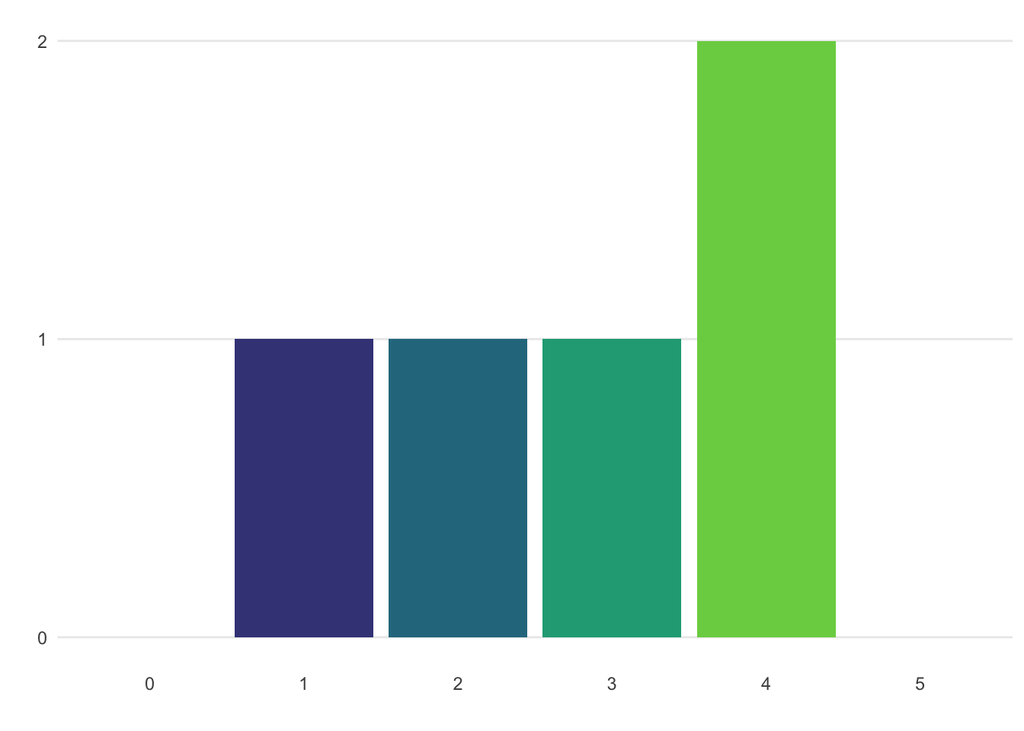

```r
mark_dist(marks, "mark", scale = 0:5)
```

You can facet the marks by any categorical columns.

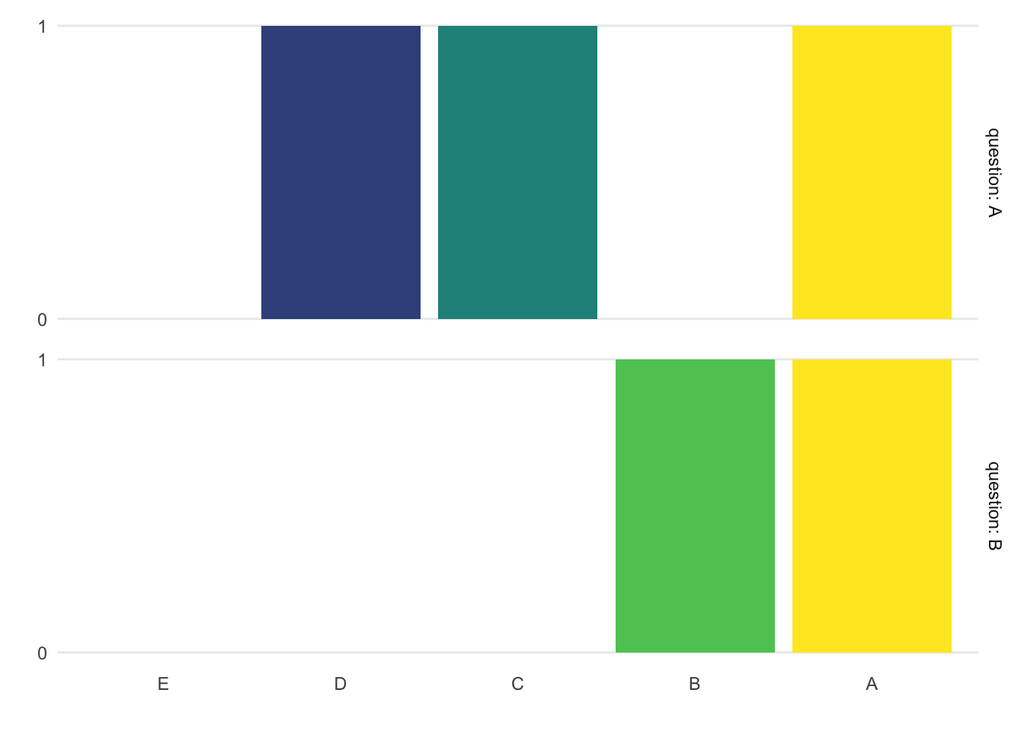

```r
mark_dist(marks, "grade", facet_by = "question",
          scale = c("E", "D", "C", "B", "A"))
```

You can also show a plot of individual criteria categories. For example, the demo data has three columns for Knowledge and Research (KR), Critical Evaluation (CE), and Academic Communication (AC). Each criterion is given a category 1-4, which correspond to “Needs Work”, “Acceptable”, “Good”, and “Outstanding”. You have to set up the list of columns and categories like for Category Tables above.

The default plot has the criteria columns across the x-axis and the categories represented by colours. You can facet the plot by any columns in the table.

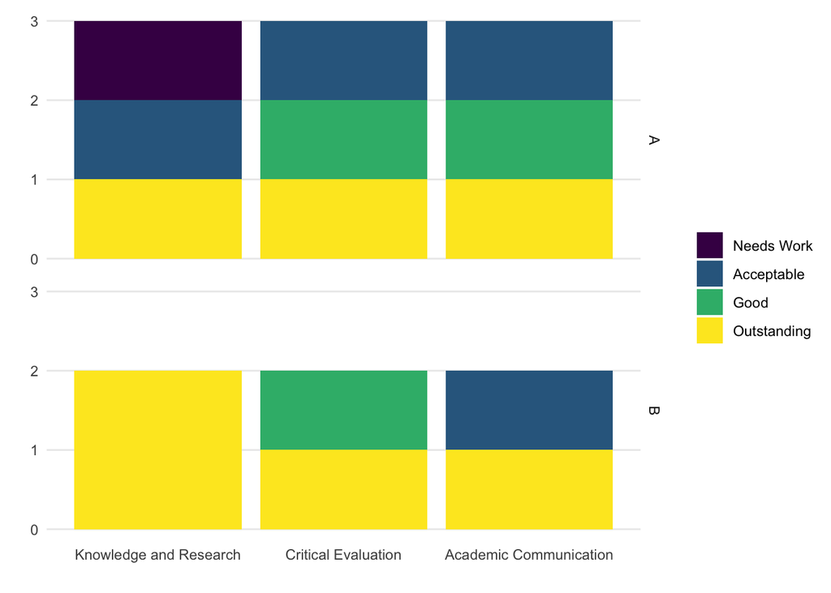

```r
cat_dist(marks, cols, cats, facet_by = "question")
```

Alternatively, you can set `xaxis = "cat"` to display the categories across the x-axis and facet by criteria in addition to any other columns.

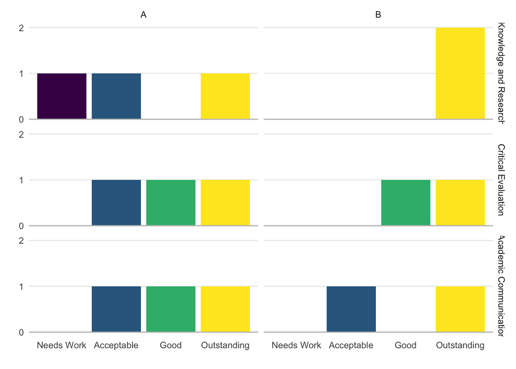

```r
cat_dist(marks, cols, cats, xaxis = "cat", facet_by = "question")
```